# MassEnviroScreen Cumulative Burden Score - A Supplement for Environmental Justice Prioritization

## Introduction and purpose

This document presents a tool for identifying or prioritizing the most environmentally vulnerable or burdened communities in Massachusetts based on a cumulative burden score that incorporates exposure to pollution and climate risks and the presence of sensitive or vulnerable populations, as well as whether the community meets criteria related to lower household income. It is intended to act as a supplement to the Massachusetts Environmental Justice Population definition.

This tool - MassEnviroScreen - is a hybrid approach that utilizes elements of the current [Massachusetts Environmental Justice Population definition](https://www.mass.gov/info-details/environmental-justice-populations-in-massachusetts), and a cumulative burden mapping approach. The cumulative burdens mapping approach is modeled on those used by [California EPA’s CalEnviroScreen tool](https://oehha.ca.gov/calenviroscreen) and the [Colorado EnviroScreen tool](https://www.cohealthmaps.dphe.state.co.us/COEnviroscreen_2/). The California and Colorado tools utilize a ‘cumulative impact score’ to describe the relative environmental burden of communities across the state and to prioritize those that are most burdened. California defines cumulative impacts as “the exposures, public health or environmental effects from the combined emissions and discharges, in a geographic area, including environmental pollution from all sources, whether single or multi-media, routinely, accidentally, or otherwise released.” Impacts consider “sensitive populations and socio-economic factors, where applicable and to the extent data are available.” The Colorado tool augments the CalEnviroScreen approach by adding climate risks, which is the approach followed here.

A ‘cumulative burden score’ is a numerical value that ranks every community (i.e., census block group) on a scale from 0 to 100. Higher values indicate greater cumulative burden. These values also represent percentile ranks, which means that a community’s score also indicates the percentage of scores in a group that are equal to or lower than a given score. For example, a census block group with a score of 50 (50th percentile) means that its cumulative burden score is equal to or higher than 50% of census block groups in the state. In this model, we follow California’s example of using a score of 75 (the 75th percentile) as one of the thresholds for identifying the most impacted or ‘Burdened Areas.’ Census block groups with a minimum score of 75 experience cumulative burdens that are equal to or higher than 75% of block groups in the state. In other words, these block group represent the top 25% of cumulative burden scores in Massachusetts.

To define “Burdened Areas” in this tool, cumulative burden percentile scores of 75 or higher are combined with one of the [existing Massachusetts EJ criteria](https://www.mass.gov/info-details/environmental-justice-populations-in-massachusetts) for low income.

**Burdened Areas are communities (i.e., census block groups) that meet one or more of the following criteria:**

- cumulative burden percentile score (i.e, MassEnviroScore) of 75 or greater, OR
- annual median household income is 65 percent or less of the statewide annual median household income

Figure 1 is an interactive map that displays ‘Burdened Areas’ (census block groups in red), as defined above. Click on a block group to see its MassEnviroScreen percentile score and the subscores (described in more detail later in the technical documentation) that comprise that cumulative burden, as well as other details. Text in red indicates a criterion’s threshold is exceeded or met. Text in blue indicates a criterion’s threshold is not exceeded or met. Select the checkbox next to ‘MA EJ Populations’ (upper right corner) to compare these Burdened Areas with block groups identified as Environmental Justice Populations under Massachusetts law. Finally, activate the ‘MassEnviroScore’ radio button to see cumulative burden scores for every census block group across the state.

[interactive chart not shown]

Figure 1

## MassEnviroScreen scoring methodology

The MassEnviroScreen cumulative burden score model is based on three components representing Pollution and Climate Burden – Exposures and Environmental Effects and Climate Risks – and two components representing Population Characteristics – Sensitive Populations (e.g., in terms of health status and age) and Socioeconomic Factors.

### Formula for calculating MassEnviroScreen Score

After the components are scored within Pollution Burden and Climate Risk or Population Characteristics, the scores are combined as follows to calculate the overall MassEnviroScreen Score:

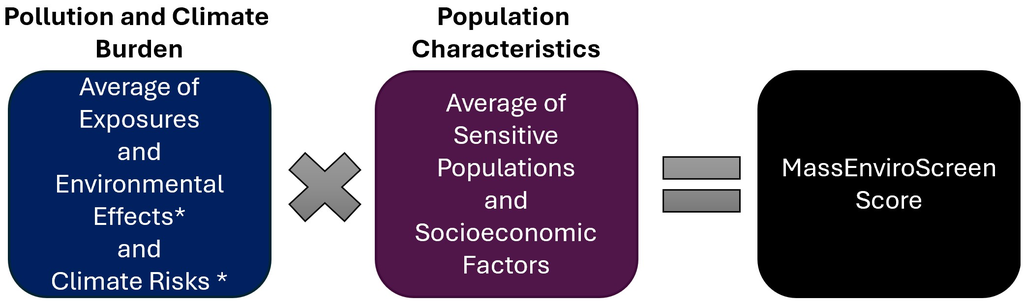

* The Environmental Effects and Climate Risks scores were weighted half as much as the Exposures score.

Scores for the pollution burden and climate risk and population characteristics categories are multiplied (rather than added, for example). This multiplication approach is based on research which shows that socioeconomic and health/sensitivity factors are “effect modifiers” that multiply the risks posed by pollutants and climate risks. Various environmental health and emergency response organizations use a similar scoring system: *Risk = Threat x Vulnerability*.

Within the MassEnviroScreen score map, clicking on individual census block groups shows both the final MassEnviroScreen percentile score as well as the Pollution and Climate Burden and the Sensitive Pop SubScores. The Pollution and Climate Burden Subscore represents the percentile rank (0 - 100) of the block group for averaged pollution burden and climate risk component indicators. Similarly, the Sensitive Pop SubScore represents the percentile rank (0 - 100) of the block group for averaged population characteristics component indicators.

### Model indicators

The MassEnviroScreen score model is computed from 30 statewide environmental, socioeconomic, and health indicators. These indicators are listed in Table 1 below. Details and data sources for model indicators can be found in the MassEnviroScreen Documentation. The complete code for generating MassEnviroScreen is available at https://github.com/profLuna/MassEnviroScreen. A CSV file with indicator values for all census block groups is available [here](https://github.com/profLuna/MassEnviroScreen/blob/main/MassEnviroScreenUBAs.csv).

Table 1: MassEnviroScreen Score Indicators

| Pollution and Climate Burden Environmental Exposures | Pollution and Climate Burden Environmental Effects | Pollution and Climate Burden Climate Risks | Population Characteristics Sensitive Populations | Population Characteristics Socioeconomic Factors |
| --- | --- | --- | --- | --- |
| PM2.5 | Pollution Cleanup Sites | Drought | Pediatric Asthma | Adults without a High School degree |
| Ozone | Groundwater Threats | Wildfire Risk | Low Birth Weight Infants | Housing Burdened Low Income Households |
| Nitrogen dioxide (NO2) | Hazardous Waste Generators and Facilities | Flood Risk | Elevated Blood Lead Levels in Children | Linguistically Isolated Households |
| Diesel Particulate Matter | Solid Waste Sites and Facilities | Extreme Heat Days | Premature Mortality | Poverty |
| Drinking Water Non-compliance | Impaired Water Bodies |  | Adult High Blood Pressure | Unemployment |
| Air Toxics Cancer Risk |  |  | Coronary Heart Disease |  |
| Air Toxics Respiratory Hazard |  |  | Chronic Obstructive Pulmonary Disease |  |
| Proximity to Heavy Traffic |  |  | Adult Cancer |  |

## Comparison with Massachusetts Environmental Justice Populations

There are several key differences between the MassEnviroScreen model approach and the Massachusetts Environmental Justice Population definition:

- The MA EJ Population definition is based on three demographic criteria - percent minority, OR percent limited English speaking households, OR percent households below 65% of statewide median household income.
- MassEnviroScreen defines “Burdened Areas” based on a cumulative burden score that integrates demographic criteria, health status, and environmental conditions across 30 indicators, OR percent of households at or below 65% of statewide median household income.
- MassEnviroScreen does not use race or ethnicity as indicators.

Both approaches, however, are based on important decisions about which indicators to use, and what threshold to use for prioritization. The latter are important policy decisions that may not be resolved by a technical analysis.

### Coverage of the state

Table 2: Criteria for Burdened Areas

| BA Criteria | Number of Block Groups | Pct of BAs | Pct of State Block Groups |
| --- | --- | --- | --- |
| MassEnviroScreen Score >= 75%tile | 1305 | 76.9% | 25.5% |
| Median Household Income <= 65% MA | 996 | 58.7% | 19.5% |

### Overlap with EJ criteria

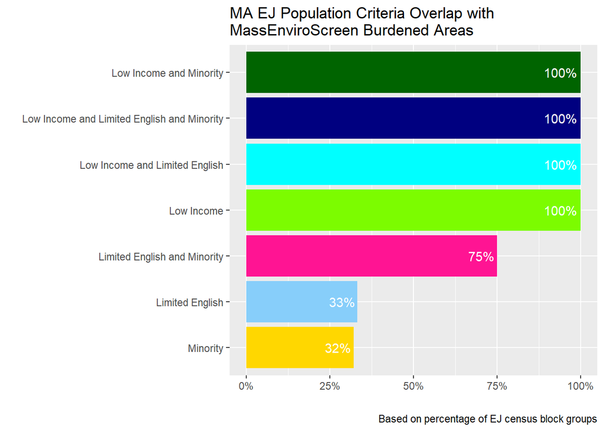

Figure 2

### MassEnviroScreen cumulative burden scores by EJ criteria

Figure 3 shows the distribution of MassEnviroScreen cumulative burden scores for block groups meeting each of the environmental justice criteria. In comparison to non-EJ block groups in Massachusetts, median cumulative burden scores for six out of the seven EJ criteria are above the 50th percentile. In other words, most block groups meeting the state’s current environmental justice population definition have cumulative burden scores that are higher than 50% of block groups across the state overall. In addition, four out of the seven also have median values above the 75th percentile or threshold for Burdened Areas.

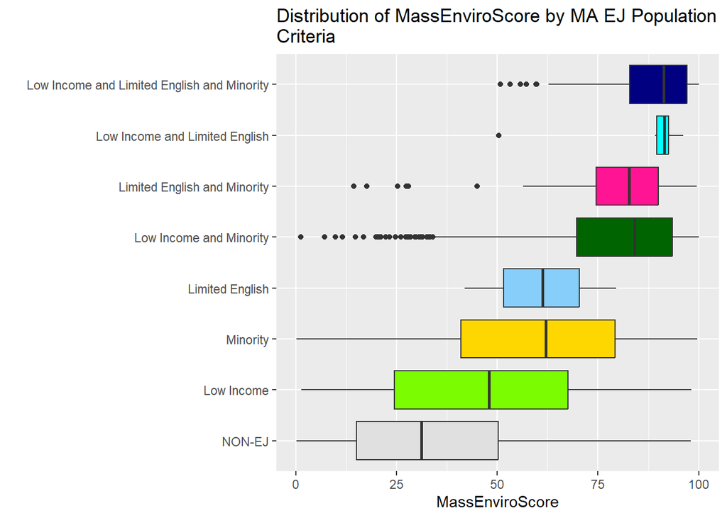

Figure 3

## Next Steps?

This report is a draft product for discussion.

Questions about this report should be directed to:

Marcos Luna, PhD Professor, Geography and Sustainability Department Salem State University Salem, MA mluna at salemstate.edu